# Final Report

Environmental System Analysis

Vajira Lasantha

10/12/2021

Exercises in this report use the base datasets bundled with R in *`datasets`* package.

### 1. Influence of feed type on the weight of chickens

An experiment was conducted to measure and compare the effectiveness of various feed supplements on the growth rate of chickens. `chickwts` dataset from R *`datasets`* package provides the data from this study.

It has 71 observations on 2 variables; Weight, a numerical variable and feed, a categorical variable.

```r
summary(chickwts)
```

```
##      weight             feed
##  Min.   :108.0   casein   :12
##  1st Qu.:204.5   horsebean:10
##  Median :258.0   linseed  :12
##  Mean   :261.3   meatmeal :11
##  3rd Qu.:323.5   soybean  :14
##  Max.   :423.0   sunflower:12
```

#### 1.1 Histogram of the weight of the chicken

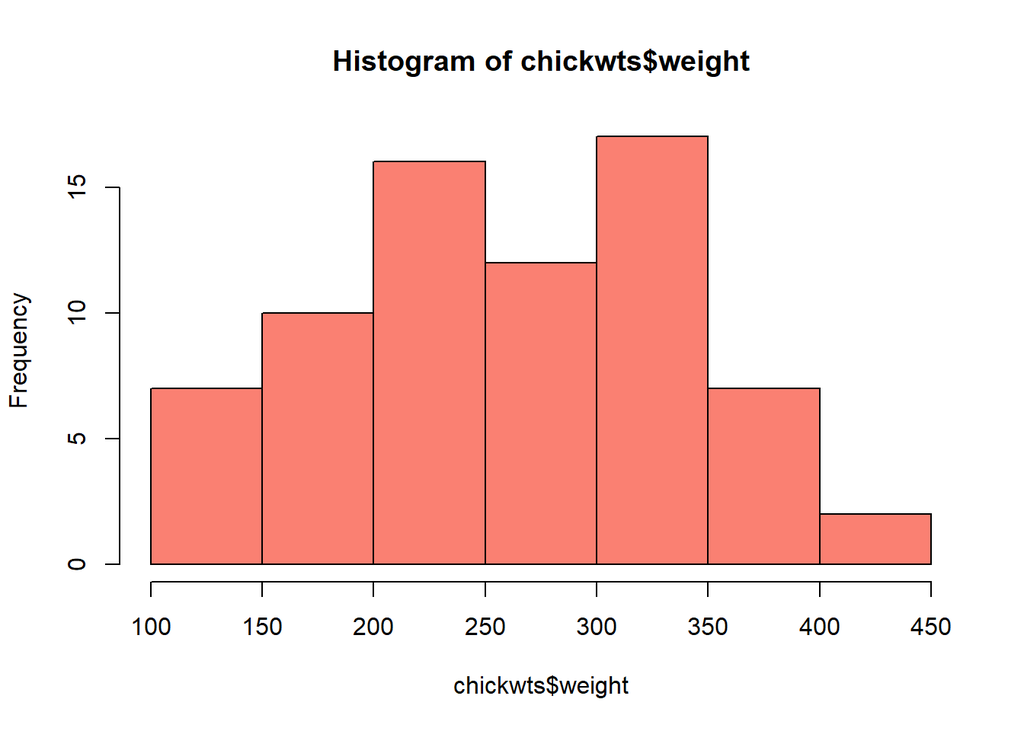

```r
hist(chickwts$weight, breaks=6, col='salmon')
```

#### 1.2 Testing for normality

```r
shapiro.test(chickwts$weight)
```

```
##
##  Shapiro-Wilk normality test
##
## data:  chickwts$weight
## W = 0.97674, p-value = 0.2101
```

Shapiro-Wilks test for the wright data gives p-value of 0.21. Because p-value in greater than 0.05, the null hypothesis that the data follows normal distribution, cannot be rejected. Weight data are normally distributed.

#### 1.4 Comparison of means

**Between two types of feeds**

Alternative hypothesis: There is a significant difference in weight between chickens fed with Soybean feed and Sunflower feed.

Null Hypothesis: There is no significant difference in weight.

First, subset the data for Soybean and Sunflower from the original `chickwts` dataset.

```r
chick2 <- chickwts[chickwts$feed=='soybean' | chickwts$feed=='sunflower', ]
```

Then the data is checked for equal variance.

```r
bartlett.test(chick2$weight~chick2$feed)
```

```
##
##  Bartlett test of homogeneity of variances
##
## data:  chick2$weight by chick2$feed
## Bartlett's K-squared = 0.12018, df = 1, p-value = 0.7288
```

In Bartlett test for equal variance, p-value is 0.72 (> 0.05). Therefore, weight data show homogeneity of variance between different feed types. Because of this, student-t test is used for comparison of means.

```r
t.test(chick2$weight~chick2$feed, var.equal=TRUE)
```

```
##
##  Two Sample t-test
##
## data:  chick2$weight by chick2$feed
## t = -4.0502, df = 24, p-value = 0.0004641
## alternative hypothesis: true difference in means between group soybean and group sunflower is not equal to 0
## 95 percent confidence interval:
##  -124.52226  -40.45393
## sample estimates:
##   mean in group soybean mean in group sunflower
##                246.4286                328.9167
```

Null hypothesis is rejected.

There is a significant difference in means between chicken fed with soybean feed and sunflower feed.

**Between all six types of feed**

```r
bartlett.test(chickwts$weight~chickwts$feed)
```

```
##
##  Bartlett test of homogeneity of variances
##
## data:  chickwts$weight by chickwts$feed
## Bartlett's K-squared = 3.2597, df = 5, p-value = 0.66
```

In Bartlett test for equal variance, p-value is 0.66 (> 0.05). Therefore, weight data show homogeneity of variance between different feed types. One-way ANOVA is used for comparison of means.

Null hypothesis: Means of the weights for six types of feed are equal.

```r
oneway.test(weight~feed, data = chickwts, var.equal = TRUE )
```

```
##
##  One-way analysis of means
##
## data:  weight and feed
## F = 15.365, num df = 5, denom df = 65, p-value = 5.936e-10
```

With the extremely small p-value, null hypothesis can be rejected. There is a significant difference between the weight of chicken fed with different types of feed.